# Assignment 3

Sonic Yao

## Introduction

This report will attempt to expose patterns of inequality by analyzing incarceration data of the US prison system. I have chose to calculate and analyze the ratio between the jailed population of each race and the total population for each race. This will highlight the difference in the proportion of jailed population based on race and could help expose areas with larger differences in these proportions.

As a summary, I have calculated the ratio between the mean population and jailed population across all counties in the year 2018 to get a view on the most current situation.

Mean jailed population : Mean total population by race

- Black = 0.0101284
- White = 0.0028595
- Native Americans = 0.0149547
- Asian Americans/Pacific Islander = 0.0014198
- Latinx = 0.0035937

From these results we can already see that the ratio for the black population is considerably higher than the white population.

## Trend over time

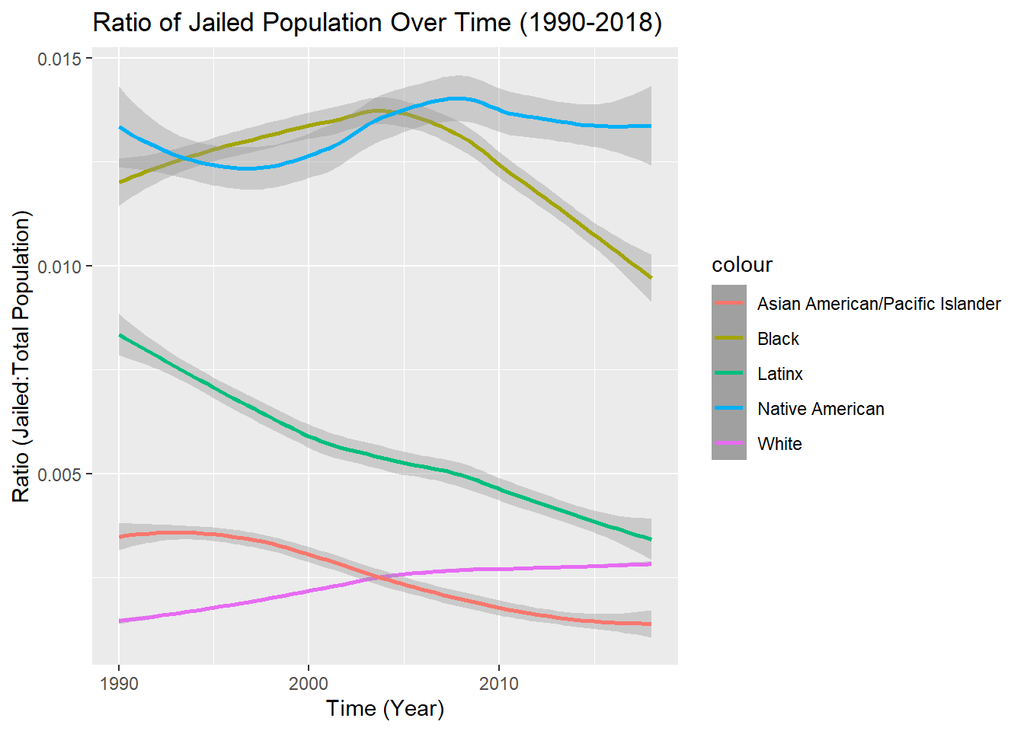

This chart helps illustrate the trend of the ratio of the jailed population over time. One clear pattern is the consistent positive difference between the trend line for Black people and White people. Although the ratio of jailed Black people are decreasing, it is still far from the ratio of White people, highlighting the unfair treatment of the justice system.

## Variable Comparison

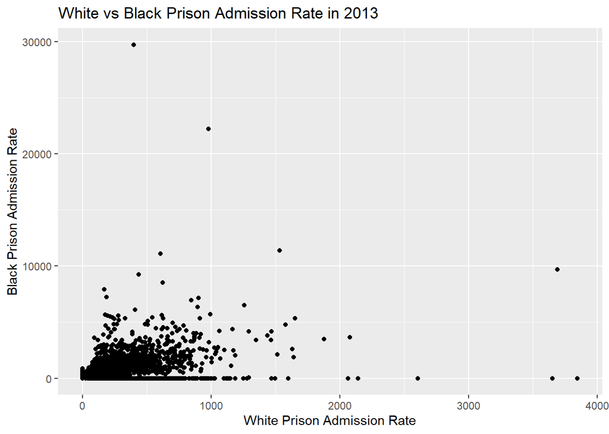

## Map Chart

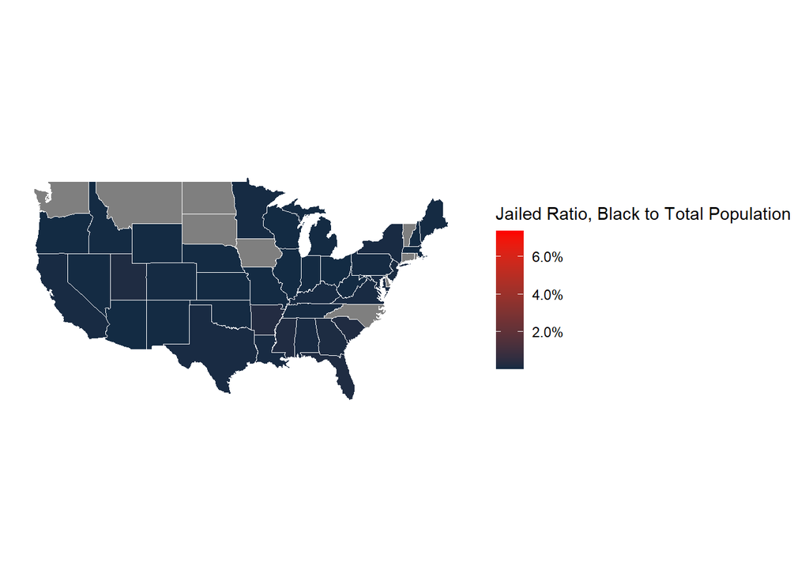